# Generación del modelo de datos

```r
library(tidyverse)
library(caret)
```

```r
library(ggcorrplot)
```

## Pregunta

¿Se puede determinar el Índice de Desarrollo Humano a partir de los datos sobre industrialización, infraestructuras e innovación?

## Lectura de los datos

A continuación se lleva a cabo la lectura de los datos provenientes de la ejecución del archivo “procesado_clasificacion.Rmd”, se que corresponden con los asociados al objetivo 9, que es el asociado a los datos sobre industrialización, infraestructuras e innovación, dispuestos cada uno de los indicadores en columnas e integrada otra fuente de datos para adherir el Índice de Desarrollo Humano como columna.

A este dataset leido desde un fichero csv se le eliminan las variables que tienen todos sus avlores nulos y posteriormente se imprimen los valores más representativos de cada columna (máximo, mínimo, media, número de valores nulos, etc.)

```r
dt <- read_delim('datos_onu/data/goal_9_measure_all_data.csv', delim=",", na = c("", "NA"), quoted_na=TRUE)
dt <- dt %>% select(-Var.23)
# Elimino las variables donde todos los valores son nulos
dt <- dt[ , colSums(is.na(dt)) < nrow(dt)]
# invalid_cols = c(1, 2, 24) # Drop column Arrival.Delay.in.Minutes (contains misses values)
# dt <- dt[, -invalid_cols]
# colnames(dt)[ncol(dt)] <- "HDI_categorical"
summary(dt)
```

```
##    Country               Year
##  Length:4762        Min.   :2000
##  Class :character   1st Qu.:2006
##  Mode  :character   Median :2013
##                     Mean   :2012
##                     3rd Qu.:2018
##                     Max.   :2019
##
##  Manufacturing.value.added.per.capita..constant.2015.United.States.dollars.
##  Min.   :    2.0
##  1st Qu.:  182.7
##  Median :  585.8
##  Mean   : 1887.7
##  3rd Qu.: 1919.3
##  Max.   :51275.6
##
##  Total.official.flows.for.infrastructure..by.recipient.countries..millions.of.constant.2018.United.States.dollars.
##  Min.   :  -0.21
##  1st Qu.:  15.34
##  Median :  86.22
##  Mean   : 307.47
##  3rd Qu.: 281.72
##  Max.   :7150.04
##  NA's   :1754
##  Manufacturing.value.added.as.a.proportion.of.GDP...
##  Min.   : 0.36
##  1st Qu.: 6.30
##  Median :11.03
##  Mean   :11.71
##  3rd Qu.:15.69
##  Max.   :50.82
##
##  Proportion.of.medium.and.high.tech.industry.value.added.in.total.value.added...
##  Min.   : 0.26
##  1st Qu.: 8.38
##  Median :19.61
##  Mean   :23.82
##  3rd Qu.:36.60
##  Max.   :88.26
##  NA's   :2386
```

[output cut: 121 more lines]

```
##  Min.   :1.494e+09                                             Min.   :0.2620
##  1st Qu.:1.697e+09                                             1st Qu.:0.5790
##  Median :1.697e+09                                             Median :0.7300
##  Mean   :1.677e+09                                             Mean   :0.7011
##  3rd Qu.:1.697e+09                                             3rd Qu.:0.8240
##  Max.   :1.697e+09                                             Max.   :0.9570
##  NA's   :4748                                                  NA's   :569
##  HDI_categorical
##  Length:4762
##  Class :character
##  Mode  :character
##
##
##
##
```

Hacemos un estudio de los valores nulos obteniendo el número de ellos presentes en el dataset.

```r
sum(is.na(dt))
```

```
## [1] 57258
```

```r
mean(is.na(dt))
```

```
## [1] 0.5009975
```

Vamos a pintar un histograma para ver en qué cuales son los valores más comunes de HDI o IDH para los países del mundo.

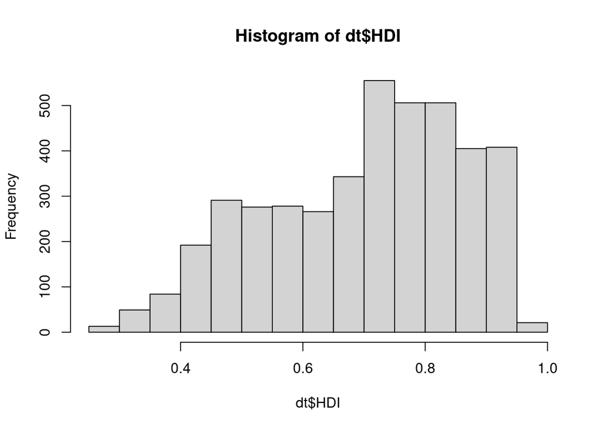

```r
hist(dt$HDI)
```

En este histograma se puede ver que la mayoría de los países se concentran entre 0.7 y 0.95, por lo que podemos decir que la mayoría de ellos tienen un IDH alto o muy alto.

A continuación vamos a identificar cuales son las columnas que contienen algun valor nulo.

```r
list_na <- colnames(dt)[ apply(dt, 2, anyNA) ]
list_na
```

```
##  [1] "Total.official.flows.for.infrastructure..by.recipient.countries..millions.of.constant.2018.United.States.dollars."
##  [2] "Proportion.of.medium.and.high.tech.industry.value.added.in.total.value.added..."
##  [3] "Proportion.of.population.covered.by.at.least.a.2G.mobile.network..."
##  [4] "Manufacturing.employment.as.a.proportion.of.total.employment..."
##  [5] "Proportion.of.population.covered.by.at.least.a.3G.mobile.network..."
##  [6] "Proportion.of.small.scale.industries.with.a.loan.or.line.of.credit..."
##  [7] "Passenger.volume..passenger.kilometres...by.mode.of.transport"
##  [8] "Proportion.of.population.covered.by.at.least.a.4G.mobile.network..."
##  [9] "Freight.volume..by.mode.of.transport..tonne.kilometres."
## [10] "Carbon.dioxide.emissions.per.unit.of.manufacturing.value.added..kilogrammes.of.CO2.per.constant.2010.United.States.dollars."
## [11] "Carbon.dioxide.emissions.per.unit.of.GDP..kilogrammes.of.CO2.per.constant.2010.United.States.dollars."
## [12] "Carbon.dioxide.emissions.from.fuel.combustion..millions.of.tonnes."
## [13] "Research.and.development.expenditure.as.a.proportion.of.GDP..."
## [14] "Researchers..in.full.time.equivalent..per.million.inhabitants..per.1000.000.population."
## [15] "Proportion.of.small.scale.industries.in.total.industry.value.added..."
## [16] "Container.port.traffic..maritime.transport..twenty.foot.equivalent.units...TEUs."
## [17] "Proportion.of.the.rural.population.who.live.within.2.km.of.an.all.season.road"
## [18] "Freight.loaded.and.unloaded..maritime.transport..metric.tons."
## [19] "HDI"
## [20] "HDI_categorical"
```

```r
wrap.it <- function(x, len)
{
  x <- gsub("\\.", " ", x)
  sapply(x, function(y) paste(strwrap(y, len),
                              collapse = "\n"),
         USE.NAMES = FALSE)
}


# Call this function with a list or vector
wrap.labels <- function(x, len)
{
  if (is.list(x))
  {
    lapply(x, wrap.it, len)
  } else {
    wrap.it(x, len)
  }
}
```

Con estas podremos representar de manera horizontal y reduciendo el tamaño de las etiquetas asociadas a los nombres de las columnas del dataset.

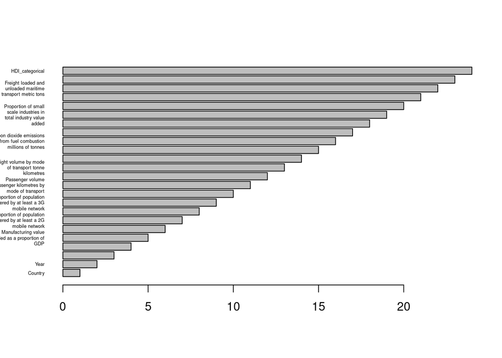

```r
null_values <- colSums(is.na(dt))
wr.lap <- wrap.labels(rownames(as.data.frame(null_values)), 25)
barplot(1:length(null_values), names.arg = wr.lap, horiz = T, las = 1, cex.names = 0.4)
```

```r
name <- which(names(dt) == "Country" | names(dt) == "HDI_categorical")
data_filtered <- dt[, -name]
# ggcorrplot(cor(data_filtered))
```

Posteriormente extraemos un dataframe con los nombres de las variables que contienen valores nulos y su media asociada.

```r
average_missing <- apply(data_filtered[ , colnames(data_filtered) %in% list_na],
      2,
      mean,
      na.rm = TRUE)
avg_missing_df <- as.data.frame(average_missing)
avg_missing_df
```

```
##                                                                                                                             average_missing
## Total.official.flows.for.infrastructure..by.recipient.countries..millions.of.constant.2018.United.States.dollars.              3.074739e+02
## Proportion.of.medium.and.high.tech.industry.value.added.in.total.value.added...                                                2.382498e+01
## Proportion.of.population.covered.by.at.least.a.2G.mobile.network...                                                            9.206321e+01
## Manufacturing.employment.as.a.proportion.of.total.employment...                                                                1.344184e+01
## Proportion.of.population.covered.by.at.least.a.3G.mobile.network...                                                            8.361211e+01
## Proportion.of.small.scale.industries.with.a.loan.or.line.of.credit...                                                          2.880055e+01
## Passenger.volume..passenger.kilometres...by.mode.of.transport                                                                  9.083647e+10
## Proportion.of.population.covered.by.at.least.a.4G.mobile.network...                                                            7.179198e+01
## Freight.volume..by.mode.of.transport..tonne.kilometres.                                                                        6.124859e+10
## Carbon.dioxide.emissions.per.unit.of.manufacturing.value.added..kilogrammes.of.CO2.per.constant.2010.United.States.dollars.    6.636758e-01
## Carbon.dioxide.emissions.per.unit.of.GDP..kilogrammes.of.CO2.per.constant.2010.United.States.dollars.                          2.601222e-01
## Carbon.dioxide.emissions.from.fuel.combustion..millions.of.tonnes.                                                             1.124256e+02
## Research.and.development.expenditure.as.a.proportion.of.GDP...                                                                 9.125633e-01
## Researchers..in.full.time.equivalent..per.million.inhabitants..per.1000.000.population.                                        2.026438e+03
## Proportion.of.small.scale.industries.in.total.industry.value.added...                                                          1.256386e+01
## Container.port.traffic..maritime.transport..twenty.foot.equivalent.units...TEUs.                                               6.022256e+06
## Proportion.of.the.rural.population.who.live.within.2.km.of.an.all.season.road                                                  6.055000e+01
## Freight.loaded.and.unloaded..maritime.transport..metric.tons.                                                                  1.677325e+09
## HDI                                                                                                                            7.010558e-01
```

Y finalmente aplicamos una función a todas las filas del dataset, de manera que si contiene valores nulos, se sustituye por la media del resto de valores.

```r
df_impute_mean <- data.frame(
    sapply(
        dt,
        function(x) ifelse(is.na(x),
            mean(x, na.rm = TRUE),
            x)))
```

Con esto comenzamos la preparación de los datos para responder a nuestra pregunta. La capacidad de determinar el IDH a partir de los datos de industrialización, infraestruturas e innovación lo responderemos entrenando un modelo de clasificación, que solamente tomará como entrada los datos del objetivo y dará como salida el nivel de IDH asociado al país. Si el accuracy del modelo entrenado es bastante alto (más de un 85%) podremos responder afirmativamente a la pregunta.

```r
data <- df_impute_mean %>% select(-Country, -HDI)
data <- data %>% drop_na()
data$HDI_categorical <- factor(data$HDI_categorical, exclude = NULL)
anyNA(data$HDI_categorical)
```

```
## [1] FALSE
```

Con estas celdas comprobamos que el valor de nulos es 0 en todo el dataset.

```r
sum(is.na(data))
```

```
## [1] 0
```

```r
colSums(is.na(data))
```

```
##                                                                                                                        Year
##                                                                                                                           0
##                                                  Manufacturing.value.added.per.capita..constant.2015.United.States.dollars.
##                                                                                                                           0
##           Total.official.flows.for.infrastructure..by.recipient.countries..millions.of.constant.2018.United.States.dollars.
##                                                                                                                           0
##                                                                         Manufacturing.value.added.as.a.proportion.of.GDP...
##                                                                                                                           0
##                                             Proportion.of.medium.and.high.tech.industry.value.added.in.total.value.added...
##                                                                                                                           0
##                                                         Proportion.of.population.covered.by.at.least.a.2G.mobile.network...
##                                                                                                                           0
##                                                             Manufacturing.employment.as.a.proportion.of.total.employment...
##                                                                                                                           0
##                                                         Proportion.of.population.covered.by.at.least.a.3G.mobile.network...
##                                                                                                                           0
##                                                       Proportion.of.small.scale.industries.with.a.loan.or.line.of.credit...
##                                                                                                                           0
##                                                               Passenger.volume..passenger.kilometres...by.mode.of.transport
##                                                                                                                           0
##                                                         Proportion.of.population.covered.by.at.least.a.4G.mobile.network...
##                                                                                                                           0
##                                                                     Freight.volume..by.mode.of.transport..tonne.kilometres.
##                                                                                                                           0
## Carbon.dioxide.emissions.per.unit.of.manufacturing.value.added..kilogrammes.of.CO2.per.constant.2010.United.States.dollars.
##                                                                                                                           0
##                       Carbon.dioxide.emissions.per.unit.of.GDP..kilogrammes.of.CO2.per.constant.2010.United.States.dollars.
##                                                                                                                           0
##                                                          Carbon.dioxide.emissions.from.fuel.combustion..millions.of.tonnes.
##                                                                                                                           0
##                                                              Research.and.development.expenditure.as.a.proportion.of.GDP...
##                                                                                                                           0
##                                     Researchers..in.full.time.equivalent..per.million.inhabitants..per.1000.000.population.
##                                                                                                                           0
##                                                       Proportion.of.small.scale.industries.in.total.industry.value.added...
##                                                                                                                           0
##                                            Container.port.traffic..maritime.transport..twenty.foot.equivalent.units...TEUs.
##                                                                                                                           0
##                                               Proportion.of.the.rural.population.who.live.within.2.km.of.an.all.season.road
##                                                                                                                           0
##                                                               Freight.loaded.and.unloaded..maritime.transport..metric.tons.
##                                                                                                                           0
##                                                                                                             HDI_categorical
##                                                                                                                           0
```

Las columnas de datos con pocos cambios en los datos representan muy poca información. No hay que olvidar que la varianza depende del rango, por lo tanto, antes de tratar las columnas de datos con baja varianza, debemos normalizarlas. En R se puede utilizar la función nearZeroVar() de la librería caret.

```r
nearZeroVar(data, saveMetrics = TRUE)
```

```
##                                                                                                                               freqRatio
## Year                                                                                                                           7.571429
## Manufacturing.value.added.per.capita..constant.2015.United.States.dollars.                                                     1.076923
## Total.official.flows.for.infrastructure..by.recipient.countries..millions.of.constant.2018.United.States.dollars.            108.923077
## Manufacturing.value.added.as.a.proportion.of.GDP...                                                                            1.190476
## Proportion.of.medium.and.high.tech.industry.value.added.in.total.value.added...                                               90.363636
## Proportion.of.population.covered.by.at.least.a.2G.mobile.network...                                                            2.328063
## Manufacturing.employment.as.a.proportion.of.total.employment...                                                               46.511111
## Proportion.of.population.covered.by.at.least.a.3G.mobile.network...                                                           11.558011
## Proportion.of.small.scale.industries.with.a.loan.or.line.of.credit...                                                        326.833333
## Passenger.volume..passenger.kilometres...by.mode.of.transport                                                                569.000000
## Proportion.of.population.covered.by.at.least.a.4G.mobile.network...                                                           27.281250
## Freight.volume..by.mode.of.transport..tonne.kilometres.                                                                      720.750000
## Carbon.dioxide.emissions.per.unit.of.manufacturing.value.added..kilogrammes.of.CO2.per.constant.2010.United.States.dollars.   47.586957
## Carbon.dioxide.emissions.per.unit.of.GDP..kilogrammes.of.CO2.per.constant.2010.United.States.dollars.                         21.000000
## Carbon.dioxide.emissions.from.fuel.combustion..millions.of.tonnes.                                                           441.400000
## Research.and.development.expenditure.as.a.proportion.of.GDP...                                                                79.676471
## Researchers..in.full.time.equivalent..per.million.inhabitants..per.1000.000.population.                                      254.666667
## Proportion.of.small.scale.industries.in.total.industry.value.added...                                                       1170.000000
## Container.port.traffic..maritime.transport..twenty.foot.equivalent.units...TEUs.                                             172.785714
## Proportion.of.the.rural.population.who.live.within.2.km.of.an.all.season.road                                                345.500000
## Freight.loaded.and.unloaded..maritime.transport..metric.tons.                                                                  0.000000
## HDI_categorical                                                                                                                1.278146
##                                                                                                                             percentUnique
## Year                                                                                                                           0.47698545
## Manufacturing.value.added.per.capita..constant.2015.United.States.dollars.                                                    66.63486764
## Total.official.flows.for.infrastructure..by.recipient.countries..millions.of.constant.2018.United.States.dollars.             45.52826139
## Manufacturing.value.added.as.a.proportion.of.GDP...                                                                           39.30360124
## Proportion.of.medium.and.high.tech.industry.value.added.in.total.value.added...                                               30.98020510
## Proportion.of.population.covered.by.at.least.a.2G.mobile.network...                                                            8.63343668
## Manufacturing.employment.as.a.proportion.of.total.employment...                                                                5.96231815
## Proportion.of.population.covered.by.at.least.a.3G.mobile.network...                                                            9.32506559
## Proportion.of.small.scale.industries.with.a.loan.or.line.of.credit...                                                          5.12759361
## Passenger.volume..passenger.kilometres...by.mode.of.transport                                                                 13.57023611
## Proportion.of.population.covered.by.at.least.a.4G.mobile.network...                                                            7.13093251
## Freight.volume..by.mode.of.transport..tonne.kilometres.                                                                       12.44932030
## Carbon.dioxide.emissions.per.unit.of.manufacturing.value.added..kilogrammes.of.CO2.per.constant.2010.United.States.dollars.    5.67612688
## Carbon.dioxide.emissions.per.unit.of.GDP..kilogrammes.of.CO2.per.constant.2010.United.States.dollars.                          1.88409254
## Carbon.dioxide.emissions.from.fuel.combustion..millions.of.tonnes.                                                            41.04459814
## Research.and.development.expenditure.as.a.proportion.of.GDP...                                                                 7.65561650
```

[output cut: 37 more lines]

```
## Proportion.of.population.covered.by.at.least.a.3G.mobile.network...                                                         FALSE
## Proportion.of.small.scale.industries.with.a.loan.or.line.of.credit...                                                        TRUE
## Passenger.volume..passenger.kilometres...by.mode.of.transport                                                               FALSE
## Proportion.of.population.covered.by.at.least.a.4G.mobile.network...                                                          TRUE
## Freight.volume..by.mode.of.transport..tonne.kilometres.                                                                     FALSE
## Carbon.dioxide.emissions.per.unit.of.manufacturing.value.added..kilogrammes.of.CO2.per.constant.2010.United.States.dollars.  TRUE
## Carbon.dioxide.emissions.per.unit.of.GDP..kilogrammes.of.CO2.per.constant.2010.United.States.dollars.                        TRUE
## Carbon.dioxide.emissions.from.fuel.combustion..millions.of.tonnes.                                                          FALSE
## Research.and.development.expenditure.as.a.proportion.of.GDP...                                                               TRUE
## Researchers..in.full.time.equivalent..per.million.inhabitants..per.1000.000.population.                                     FALSE
## Proportion.of.small.scale.industries.in.total.industry.value.added...                                                       FALSE
## Container.port.traffic..maritime.transport..twenty.foot.equivalent.units...TEUs.                                            FALSE
## Proportion.of.the.rural.population.who.live.within.2.km.of.an.all.season.road                                                TRUE
## Freight.loaded.and.unloaded..maritime.transport..metric.tons.                                                                TRUE
## HDI_categorical                                                                                                             FALSE
```

```r
data <- data %>% select(-starts_with("Freight.loaded.and.unloaded..maritime.transport..metric.tons."))
```

Con lo que queda eliminada la columna asociada a la medida “Freight.loaded.and.unloaded..maritime.transport..metric.tons.”.

A continuación llevamos a cabo la división entre conjunto de entrenamiento (80%) y pruebas (20%) del dataset, y la configuración necesaria para posteriormente entrenar el modelo ML a partir de estos datos. En este problema hemos obtado por RandomForest, al probar más cantidad de algoritmos y maximizar las posibilidades de obtener buenos rendimientos.

```r
# Data Partition
library(randomForest)
ind <- sample(2, nrow(data), replace = TRUE, prob = c(0.8, 0.2))


train <- data[ind==1,]
test <- data[ind==2,]

i <- c(1:20)
train[ , i] <- apply(train[ , i], 2, function(x) as.numeric(as.character(x)))
test[ , i] <- apply(test[ , i], 2, function(x) as.numeric(as.character(x)))
train$HDI_categorical <- factor(train$HDI_categorical, exclude = NULL)
test$HDI_categorical <- factor(test$HDI_categorical, exclude = NULL)

metric <- "Accuracy"


customRF <- list(type = "Classification",
                 library = "randomForest",
                 loop = NULL)

customRF$parameters <- data.frame(parameter = c("mtry", "ntree"),
                                  class = rep("numeric", 2),
                                  label = c("mtry", "ntree"))

customRF$grid <- function(x, y, len = NULL, search = "grid") {}

customRF$fit <- function(x, y, wts, param, lev, last, weights, classProbs) {
  randomForest(x, y,
               mtry = param$mtry,
               ntree=param$ntree)
}

# Etiqueta predicha
customRF$predict <- function(modelFit, newdata, preProc = NULL, submodels = NULL)
   predict(modelFit, newdata)

# Prediccion prob
customRF$prob <- function(modelFit, newdata, preProc = NULL, submodels = NULL)
   predict(modelFit, newdata, type = "prob")

customRF$sort <- function(x) x[order(x[,1]),]
customRF$levels <- function(x) x$classes




control <- trainControl(method="repeatedcv",
                        number=2,
                        verboseIter = TRUE,
                        allowParallel = TRUE)

tunegrid <- expand.grid(.mtry=c(1:15),.ntree=c(4, 10))
```

Llevamos a cabo el entrenamiento del Random Forest para clasificar las instancias entre cuatro etiquetas: “Muy Alto”, “Alto”, “Medio” o “Bajo”.

```r
set.seed(1)

custom <- train(HDI_categorical~., data=train,
                method=customRF,
                metric=metric,
                tuneGrid=tunegrid,
                trControl=control)
                #na.action=na.roughfix)

summary(custom)
```

```
##                 Length Class      Mode
## call                5  -none-     call
## type                1  -none-     character
## predicted        3351  factor     numeric
## err.rate           50  -none-     numeric
## confusion          20  -none-     numeric
## votes           13404  matrix     numeric
## oob.times        3351  -none-     numeric
## classes             4  -none-     character
## importance         20  -none-     numeric
## importanceSD        0  -none-     NULL
## localImportance     0  -none-     NULL
## proximity           0  -none-     NULL
## ntree               1  -none-     numeric
## mtry                1  -none-     numeric
## forest             14  -none-     list
## y                3351  factor     numeric
## test                0  -none-     NULL
## inbag               0  -none-     NULL
## xNames             20  -none-     character
## problemType         1  -none-     character
## tuneValue           2  data.frame list
## obsLevels           4  -none-     character
## param               0  -none-     list
```

A continuación representamos un resumen de los resultados que se han obtenido con el entrenamiento.

```r
summary(custom)
```

```
##                 Length Class      Mode
## call                5  -none-     call
## type                1  -none-     character
## predicted        3351  factor     numeric
## err.rate           50  -none-     numeric
## confusion          20  -none-     numeric
## votes           13404  matrix     numeric
## oob.times        3351  -none-     numeric
## classes             4  -none-     character
## importance         20  -none-     numeric
## importanceSD        0  -none-     NULL
## localImportance     0  -none-     NULL
## proximity           0  -none-     NULL
## ntree               1  -none-     numeric
## mtry                1  -none-     numeric
## forest             14  -none-     list
## y                3351  factor     numeric
## test                0  -none-     NULL
## inbag               0  -none-     NULL
## xNames             20  -none-     character
## problemType         1  -none-     character
## tuneValue           2  data.frame list
## obsLevels           4  -none-     character
## param               0  -none-     list
```

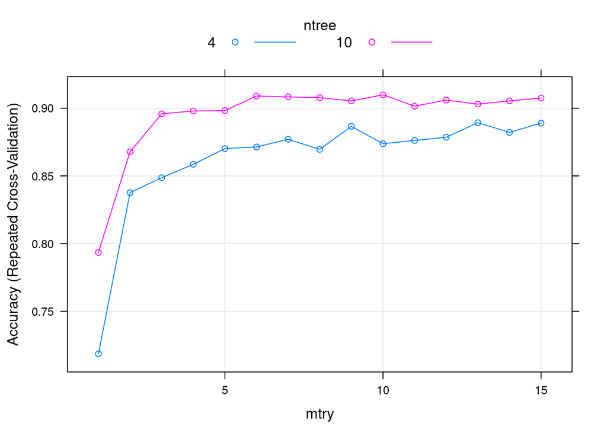

```r
plot(custom)
```

A continuación generamos el fichero necesario para almacenar el modelo.

```r
saveRDS(custom, "model_rf_HDI.rds")
```

Finalmente llevamos a cabo la predicción y pintamos la matriz de confusión utilizando datos de prueba.

```r
tunegrid <- expand.grid(.mtry=c(10),.ntree=c(60))

set.seed(1)

best_model <- train(HDI_categorical~., data=train,
                method=customRF,
                metric=metric,
                tuneGrid=tunegrid,
                trControl=control)
predict_rf_model <- predict(custom, test)
conf_mat <- confusionMatrix(predict_rf_model, as.factor(test$HDI_categorical))

confusionMatrix(predict_rf_model, as.factor(test$HDI_categorical))
```

```
## Confusion Matrix and Statistics
##
##           Reference
## Prediction Alto Bajo Medio Muy Alto
##   Alto      186    1     8       10
##   Bajo        2  163     7        0
##   Medio       9    5   167        0
##   Muy Alto    5    0     0      279
##
## Overall Statistics
##
##                Accuracy : 0.9442
##                  95% CI : (0.9265, 0.9587)
##     No Information Rate : 0.3432
##     P-Value [Acc > NIR] : < 2.2e-16
##
##                   Kappa : 0.9244
##
##  Mcnemar's Test P-Value : NA
##
## Statistics by Class:
##
##                      Class: Alto Class: Bajo Class: Medio Class: Muy Alto
## Sensitivity               0.9208      0.9645       0.9176          0.9654
## Specificity               0.9703      0.9866       0.9788          0.9910
## Pos Pred Value            0.9073      0.9477       0.9227          0.9824
## Neg Pred Value            0.9749      0.9910       0.9773          0.9821
## Prevalence                0.2399      0.2007       0.2162          0.3432
## Detection Rate            0.2209      0.1936       0.1983          0.3314
## Detection Prevalence      0.2435      0.2043       0.2150          0.3373
## Balanced Accuracy         0.9456      0.9756       0.9482          0.9782
```